# EX1: Identifying function and tuning parameters

# EX2 : Outliers in data and curve trends w.r.t functions

```python
a=np.random.randint(low=100, high=200, size=13)
b=np.random.randint(low=20000, high=40000, size=13)
data_set2 = pd.DataFrame({'X':a, 'YN':b})
res=data_set.append(data_set2,ignore_index=True)
res
x_coord2=res['X']
y_coord2=res['YN']
```

### Cubic Function: Curve Fitting

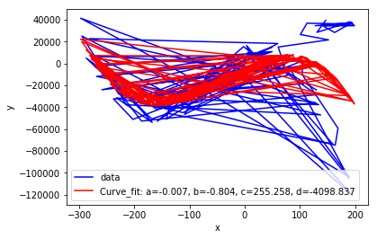

```python
def Math_Function(x, a, b, c,d):
...     return a * np.power(x,3)+ b * np.power(x,2)+ c*x + d
plotty.plot(x_coord2, y_coord2, 'b-', label='data')
coefficient, pcov = curve_fit(Math_Function, x_coord2, y_coord2)
plotty.plot(x_coord2, Math_Function(x_coord2, *coefficient), 'r-',
...          label='Curve_fit: a=%5.3f, b=%5.3f, c=%5.3f, d=%5.3f' % tuple(coefficient))
plotty.xlabel('x')
plotty.ylabel('y')
plotty.legend()
plotty.show()
```

```python
y_value=Math_Function(x_coord2,*coefficient)
list_for_errors=[]
for i in range(len(y_value)):
        list_for_errors.append((y_value[i]-y_coord2[i])**2)
sum(list_for_errors)
print('----------------------------------------------------')

print("Mean error : ",sum(list_for_errors)/len(list_for_errors))
print("\nMedian of error : ",list_for_errors[int(len(list_for_errors)/2)])

print('----------------------------------------------------')
```

```
----------------------------------------------------
Mean error :  680705158.727

Median of error :  5517054955.99
----------------------------------------------------
```

### Quadratic Function: Curve Fitting

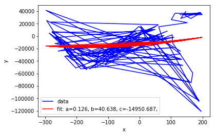

```python
def Math_Function_2(x,b, c,d):
    a=0
    return a * np.power(x,3)+ b * np.power(x,2)+ c*x + d
plotty.plot(x_coord2, y_coord2, 'b-', label='data')
coefficient_3, pcov_3 = curve_fit(Math_Function_2, x_coord2, y_coord2)
plotty.plot(x_coord2, Math_Function_2(x_coord2, *coefficient_3), 'r-', label='fit: a=%5.3f, b=%5.3f, c=%5.3f,' % tuple(coefficient_3))
plotty.xlabel('x')
plotty.ylabel('y')
plotty.legend()
plotty.show()
```

```python
y_value=Math_Function_2(x_coord,*coefficient_3)
list_for_errors=[]
for i in range(len(y_value)):
        list_for_errors.append((y_value[i]-y_coord[i])**2)
sum(list_for_errors)
print("Mean error : ",sum(list_for_errors)/len(list_for_errors))
print("\nMedian of error : ",list_for_errors[int(len(list_for_errors)/2)])

print('----------------------------------------------------')

print('\nParameters obtained for \'a\'b\'c :',coefficient_3)
```

```
Mean error :  883604696.138

Median of error :  4863464459.64
----------------------------------------------------

Parameters obtained for 'a'b'c : [  1.25678013e-01   4.06377278e+01  -1.49506870e+04]
```

### Linear Function: Curve Fitting

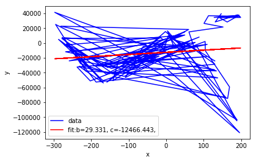

```python
def Math_Function_3(x, c,d):
    a=0
    b=0
    return a * np.power(x,3)+ b * np.power(x,2)+ c*x + d
plotty.plot(x_coord2, y_coord2, 'b-', label='data')
coefficient_4, pcov_3 = curve_fit(Math_Function_3, x_coord2, y_coord2)
plotty.plot(x_coord2, Math_Function_3(x_coord2, *coefficient_4), 'r-', label='fit:b=%5.3f, c=%5.3f,' % tuple(coefficient_4))
plotty.xlabel('x')
plotty.ylabel('y')
plotty.legend()
plotty.show()
```

```python
y_value=Math_Function_3(x_coord2,*coefficient_4)
list_for_errors=[]
for i in range(len(y_value)):
        list_for_errors.append((y_value[i]-y_coord2[i])**2)
sum(list_for_errors)
print("Mean error : ",sum(list_for_errors)/len(list_for_errors))
print("\nMedian of error : ",list_for_errors[int(len(list_for_errors)/2)])

print('----------------------------------------------------')

print('\nParameters obtained for \'a\'b :',coefficient_4)
```

```
Mean error :  963329550.644

Median of error :  9351315187.14
----------------------------------------------------

Parameters obtained for 'a'b : [    29.33089894 -12466.44328636]
```

# EX-3: 12 points to identify best fit

### Cubic Function: Curve Fitting

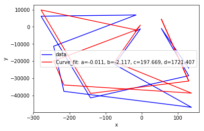

```python
plotty.plot(x, y, 'b-', label='data')
coefficient_5, pcov_5 = curve_fit(Math_Function, x, y)
plotty.plot(x, Math_Function(x, *coefficient_5), 'r-', label='Curve_fit: a=%5.3f, b=%5.3f, c=%5.3f, d=%5.3f' % tuple(coefficient_5))
plotty.xlabel('x')
plotty.ylabel('y')
plotty.legend()
plotty.show()
```

```python
y_value=Math_Function(x,*coefficient_5)
list_for_errors=[]
for i in range(len(y_value)):
        list_for_errors.append((y_value[i]-y[i])**2)
sum(list_for_errors)
print("Mean error : ",sum(list_for_errors)/len(list_for_errors))
print("\nMedian of error : ",list_for_errors[int(len(list_for_errors)/2)])

print('----------------------------------------------------')

print('\nParameters obtained for \'a\'b\'c\'d\' :',coefficient_5)
```

```
Mean error :  29367525.5574

Median of error :  73135548.4253
----------------------------------------------------

Parameters obtained for 'a'b'c'd' : [ -1.05212486e-02  -2.11702641e+00   1.97668557e+02   1.72140694e+03]
```

### Cubic Function by Gnuplot:

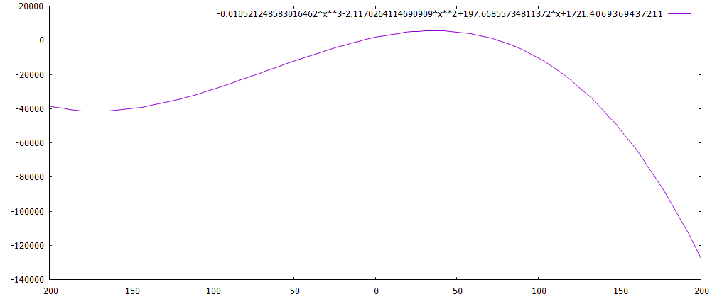

```python
from IPython.display import Image
Image(filename='Ex-3 cubic.png')
```

### Quadratic Function: Curve Fitting

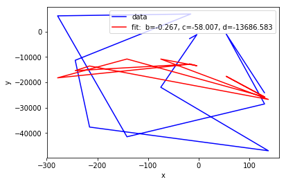

```python
plotty.plot(x, y, 'b-', label='data')
coefficient_6, pcov_2 = curve_fit(Math_Function_2, x, y)
plotty.plot(x, Math_Function_2(x, *coefficient_6), 'r-', label='fit:  b=%5.3f, c=%5.3f, d=%5.3f' % tuple(coefficient_6))
plotty.xlabel('x')
plotty.ylabel('y')
plotty.legend()
plotty.show()
```

```python
y_value=Math_Function_2(x,*coefficient_6)
list_for_errors=[]
for i in range(len(y_value)):
        list_for_errors.append((y_value[i]-y[i])**2)
sum(list_for_errors)
print("Mean error : ",sum(list_for_errors)/len(list_for_errors))
print("\nMedian of error : ",list_for_errors[int(len(list_for_errors)/2)])

print('----------------------------------------------------')

print('\nParameters obtained for \'a\'b\'c :',coefficient_6)
```

```
Mean error :  299054552.322

Median of error :  16652547.9092
----------------------------------------------------

Parameters obtained for 'a'b'c : [ -2.66920136e-01  -5.80072059e+01  -1.36865834e+04]
```

### Quadratic Function by Gnuplot:

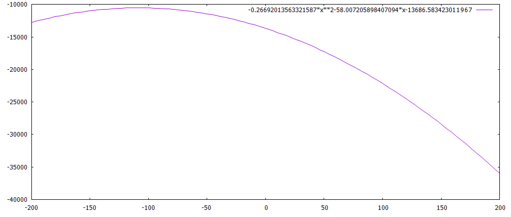

```python
from IPython.display import Image
Image(filename='Ex-3 quadratic.png')
```

### Linear Function: Curve Fitting

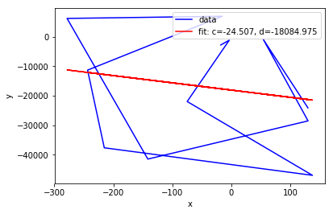

```python
plotty.plot(x, y, 'b-', label='data')
coefficient_7, pcov_2 = curve_fit(Math_Function_3, x, y)
plotty.plot(x, Math_Function_3(x, *coefficient_7), 'r-', label='fit: c=%5.3f, d=%5.3f' % tuple(coefficient_7))
plotty.xlabel('x')
plotty.ylabel('y')
plotty.legend()
plotty.show()
```

```python
y_value=Math_Function_3(x,*coefficient_7)
list_for_errors=[]
for i in range(len(y_value)):
        list_for_errors.append((y_value[i]-y[i])**2)
sum(list_for_errors)
print("Mean error : ",sum(list_for_errors)/len(list_for_errors))
print("\nMedian of error : ",list_for_errors[int(len(list_for_errors)/2)])

print('----------------------------------------------------')

print('\nParameters obtained for \'a\'b:',coefficient_7)
```

```
Mean error :  319302001.447

Median of error :  619134.714069
----------------------------------------------------

Parameters obtained for 'a'b: [   -24.50712247 -18084.97521307]
```

### Linear Function by Gnuplot:

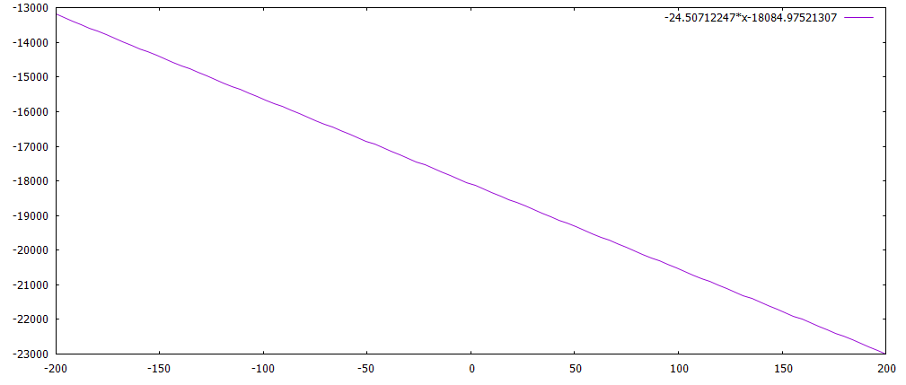

```python
from IPython.display import Image
Image(filename='Ex-3 Linear.png')
```

# EX4: Very Simple Grep and KMP Algorithm

```python
filename  = ('words.txt')
with open (filename) as f:
    read = f.readlines()

words=[]
for i in read:
    words.append(str(i[:-1]))   # Remove \n from words
```

### My Simple Code:

```python
search_pattern = input('Enter pattern to match--> ')
list(filter(lambda x:search_pattern in x, words))
```

```
Enter pattern to match--> flyer
```

```
['butterflyer', 'flyer', 'flyers', "flyer's", 'highflyer', 'high-flyer']
```

### KMP Algorithm:

### Code Reference:

https://gist.github.com/m00nlight/daa6786cc503fde12a77

```python
class KMP:


    def partial(self, pattern):
        """ Calculate partial match table: String -> [Int]"""
        ret = [0]

        for i in range(1, len(pattern)):
            j = ret[i - 1]
            while j > 0 and pattern[j] != pattern[i]:
                j = ret[j - 1]
            ret.append(j + 1 if pattern[j] == pattern[i] else j)
        return ret

    def search(self, T, P):
        """
        KMP search main algorithm: String -> String -> [Int]
        Return all the matching position of pattern string P in S
        """
        partial, ret, j = self.partial(P), [], 0

        for i in range(len(T)):
            while j > 0 and T[i] != P[j]:
                j = partial[j - 1]
            if T[i] == P[j]: j += 1
            if j == len(P):
                ret.append(i - (j - 1))
                j = 0

        return ret
```

```python
kmp = KMP()

for i in words:
    if(len(kmp.search(i,search_pattern))>0):
        print(i)
```

```
butterflyer
flyer
flyers
flyer's
highflyer
high-flyer
```

### Description:

The idea behind this was excercise was to run and test our own approach for string matching and any of the given algorithms. In my own code I ran my own approaching using filter command of python and finding the given pattern in all list of words.

Similarly in the KMP algorithm I passed the same pattern and verified the output. It was same as by my own approach.KMP algorithm Basically takes a pattern and check for the pattern in specified string if the pattern is found then the starting index of the pattern is marked and we move on the find the pattern again in the string which is left.

# EX5: Speed Comparision of fgrep & custom code:

### Multiple-Patterns by custom approach, KMP and Fgrep

### Custom Test:

```python
filename_2  = ('pattern.txt')
with open (filename_2) as f:
    read_2 = f.readlines()

pattern_words=[]
for i in read_2:
    pattern_words.append(str(i[:-1]))

print(pattern_words)


start = time()
found_list=[]
for check in pattern_words:
    found_list.append(list(filter(lambda x: check in x, words)))
end = timer()

print("\nTime Taken for above multiple patterns by my algorithm :",end - start)
```

```
['mam', 'can', 'distr', 'flye']

Time Taken for above multiple patterns by my algorithm : 0.1823303919998125
```

### KMP Test:

```python
start = time()
for i in pattern_words:
    for j in words:
        if(len(kmp.search(j,i))>0):
            pass
end = time()
print("\nTime Taken for above multiple patterns by KMP algorithm :",(end - start)/len(pattern_words))
```

```
Time Taken for above multiple patterns by KMP algorithm : 1.2686190604999865
```

### Description:

In this task I compared the running time efficiency of three approaches.i.e my own algorithm, the KMP algorithm and the fgrep that was mentioned in the excercise. In this case I worked with multiple patterns as asked in the question so here I am retrieving a file of patterns and running the same code as in excersie-4 and recording the time taken by them. Here is the comparision:

In above case the fgrep from linux terminal gave the best running time compared to my algorithm and kmp.

# EX6: Install & Try Agrep

## 1:

```python
from IPython.display import Image
Image(filename='agrep1.png')
```

[output not shown]

## 2:

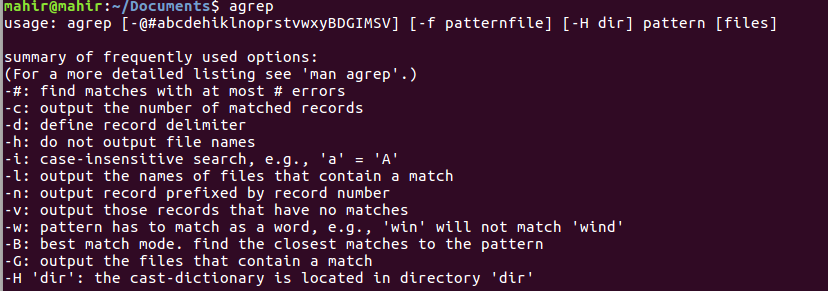

```python
from IPython.display import Image
Image(filename='agrep2.png')
```

## 3:

```python
from IPython.display import Image
Image(filename='agrep_time.png')
```

[output not shown]

## 4:

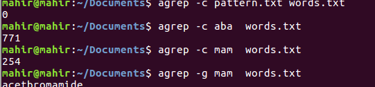

```python
from IPython.display import Image
Image(filename='agrep4.png')
```

## 5:

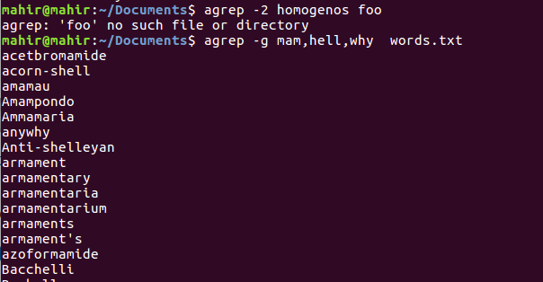

```python
from IPython.display import Image
Image(filename='agrep6.png')
```

### Description:

Well I installed this library and tested it with two things:

- The running time
- The patterns in words (Same as provided in previous exercises)